# STAT340 HW04: Models

Kai Tsuyoshi

4/10/2022

Several problems inspired by ISLR. **Problems are worth 10 points each**

## Question 1

Suppose we have a data set with five predictors, $X_{1}=\text{GPA}$, $X_{2}=\text{IQ}$, $X_{3}=\text{Level ( 1 for College and 0 for High School)}$, $X_{4}=\textrm{Interaction between GPA and IQ}$, and $X_{5}=\text{Interaction between GPA and Level}$. The response is starting salary after graduation (in thousands of dollars). Suppose we use least squares to fit the model, and get $\hat{\beta}_{0}=50$, $\hat{\beta}_{1}=20$, $\hat{\beta}_{2}=0.07$, $\hat{\beta}_{3}=35$, $\hat{\beta}_{4}=0.01$, $\hat{\beta}_{5}=-10$.

1. Which answer is correct, and why?
   1. For a fixed value of IQ and GPA, high school graduates earn more, on average, than college graduates.
   2. For a fixed value of IQ and GPA, college graduates earn more, on average, than high school graduates.
   3. For a fixed value of IQ and GPA, high school graduates earn more, on average, than college graduates provided that the GPA is high enough.
   4. For a fixed value of IQ and GPA, college graduates earn more, on average, than high school graduates provided that the GPA is high enough.
3. is correct, because $Y = \hat{\beta}_{0} + \hat{\beta}_{1}X_{1} + \hat{\beta}_{2}X_{2} + \hat{\beta}_{3}X_{3} + \hat{\beta}_{4}X_{4} + \hat{\beta}_{5}X_{5}$. Thus, salary = 50 + 20 * GPA + 0.07 * IQ + 35 * Level + 0.01 * (GPA * IQ) - 10 * (GPA * Level) For a fixed value of GPA and IQ, we take high school students, which can be represented by level=0, which yields salary = 50 + 20 * GPA + 0.07 * IQ + 0.01 * (GPA * IQ) and for a fixed value of GPA and IQ of college students represented by level = 1, salary = 50 + 20 * GPA + 0.07 * IQ + 35 + 0.01 * (GPA * IQ) - 10 * (GPA * 1)

Thus, assuming GPA is high enough, thanks to the - 10 * (GPA * 1) portion of the equation, high school graduates would earn more on average than college graduates.

2. Predict the salary of a college graduate with IQ of 110 and a GPA of 4.0.

salary = 50 + 20 * (4.0) + 0.07 * (110) + 35 + 0.01 * (4.0 * 110) - 10 * (4.0 * 1) = 137,100

3. True or false: Since the coefficient for the GPA/IQ interaction term is very small, there is very little evidence of an interaction effect. Justify your answer.

False. A small coefficient does not indicate lesser evidence of an interaction effect, because it is possible to have a large amount of evidence of a small effect. In short, statistical significance of an interaction is different from the magnitude of said interaction

## Question 2

I collect a set of data ($n=100$ observations) containing a single predictor and a quantitative response. I then fit a linear regression model to the data, as well as a separate cubic regression, i.e. $Y=$ $\beta_{0}+\beta_{1} X+\beta_{2} X^{2}+\beta_{3} X^{3}+\epsilon$

1. Suppose that the true relationship between $X$ and $Y$ is linear, i.e. $Y=\beta_{0}+\beta_{1} X+\epsilon$. Consider the training residual sum of squares (RSS) for the linear regression, and also the training RSS for the cubic regression. Would we expect one to be lower than the other, would we expect them to be the same, or is there not enough information to tell? Justify your answer.

It can be expected for the training RSS of the cubic regression to be higher than the linear regression because if the true relationship is linear, cubic regression would not do much or provide any significant information, but will still be higher than linear regression, which would follow the true regression line more closely.

2. Answer a. using test rather than training RSS.

The test population could potentially be less randomly skewed than training populous, so test RSS would also be higher for the cubic regression than linear regression perhaps even at a higher confidence.

3. Suppose that the true relationship between $X$ and $Y$ is not linear, but we don’t know how far it is from linear. Consider the training RSS for the linear regression, and also the training RSS for the cubic regression. Would we expect one to be lower than the other, would we expect them to be the same, or is there not enough information to tell? Justify your answer.

In this case, the cubic regression would follow more closely to the true regression line, the RSS of cubic regression would be lower than that of linear regression

4. Answer (c) using test rather than training RSS.

Not enough information is provided here, as there are two potential outcomes that could come from test RSS, where cubic RSS would be lower because the true regression was closer, or linear RSS is lower because the true regression was closer.

## Question 3

Suppose we collect data for a group of students in a statistics class with variables $X_{1}=\text{hours studied}$, $X_{2}=\text{undergrad GPA}$, and $Y=\text{receive an A}$. We fit a logistic regression and produce estimated coefficient, $\hat{\beta}_{0}=-6, \hat{\beta}_{1}=0.05, \hat{\beta}_{2}=1$.

1. Estimate the probability that a student who studies for $40\mathrm{h}$ and has an undergrad GPA of $3.5$ gets an A in the class.

x1 = 40 x2 = 3.5 beta0 = -6 beta1 = 0.05 beta2 = 1

eq = e^t / (1 + e^t) or 1 / (1 + e^-t)

eq = e^ (beta0 + beta1 * x1 + beta2 * x2) / 1 + e^ (beta0 + beta1 * x1 + beta2 * x2) eq = e^-0.5 / 1 + e^-0.5 eq = 0.378

2. How many hours would the student in part a. need to study to have a $50\%$ chance of getting an A in the class?

0.5 < 1 / (1 + e^-t) -> t > 1

1 < -6 + 0.05 * h + 1 * 3.5

1 < -2.5 + 0.05h

0.05h > 3.5

h > 70 hrs

## Question 4

This question uses the `titanic` dataset from the `DALEX` package. This is a **real dataset** documenting which passengers on the RMS Titanic survived.

1. Convert the `survived` variable to 0, 1 with 1 indicating a passenger who survived, and fit a logistic regression to predict survival based on all other predictors.
2. Which variables appear to be significant?
3. Interpret the coefficients for `gender`, `age`, and `fare`. Do they appear to correlate with higher or lower odds of survival? How much do the odds of survival appear to change with respect to each of these variables?
4. Do your results from c. make sense with your expectations?

```r
# make sure you have the DALEX package
library(DALEX)
str(titanic)
```

```
## 'data.frame':    2207 obs. of  9 variables:
##  $ gender  : Factor w/ 2 levels "female","male": 2 2 2 1 1 2 2 1 2 2 ...
##  $ age     : num  42 13 16 39 16 25 30 28 27 20 ...
##  $ class   : Factor w/ 7 levels "1st","2nd","3rd",..: 3 3 3 3 3 3 2 2 3 3 ...
##  $ embarked: Factor w/ 4 levels "Belfast","Cherbourg",..: 4 4 4 4 4 4 2 2 2 4 ...
##  $ country : Factor w/ 48 levels "Argentina","Australia",..: 44 44 44 15 30 44 17 17 26 16 ...
##  $ fare    : num  7.11 20.05 20.05 20.05 7.13 ...
##  $ sibsp   : num  0 0 1 1 0 0 1 1 0 0 ...
##  $ parch   : num  0 2 1 1 0 0 0 0 0 0 ...
##  $ survived: Factor w/ 2 levels "no","yes": 1 1 1 2 2 2 1 2 2 2 ...
```

```r
titanic$survived = as.numeric(titanic$survived) - 1
head(titanic)
```

```
##   gender age class    embarked       country  fare sibsp parch survived
## 1   male  42   3rd Southampton United States  7.11     0     0        0
## 2   male  13   3rd Southampton United States 20.05     0     2        0
## 3   male  16   3rd Southampton United States 20.05     1     1        0
## 4 female  39   3rd Southampton       England 20.05     1     1        1
## 5 female  16   3rd Southampton        Norway  7.13     0     0        1
## 6   male  25   3rd Southampton United States  7.13     0     0        1
```

```r
glm.titanic = glm(survived ~ ., family = "binomial", data = titanic)
summary(glm.titanic)
```

```
##
## Call:
## glm(formula = survived ~ ., family = "binomial", data = titanic)
##
## Deviance Residuals:
##     Min       1Q   Median       3Q      Max
## -2.5515  -0.6994  -0.4604   0.5660   2.6080
##
## Coefficients:
##                                Estimate Std. Error z value Pr(>|z|)
## (Intercept)                  -1.100e+01  8.744e+02  -0.013 0.989962
## gendermale                   -2.800e+00  1.697e-01 -16.501  < 2e-16 ***
## age                          -3.953e-02  5.666e-03  -6.977 3.00e-12 ***
## class2nd                     -1.251e+00  3.026e-01  -4.135 3.55e-05 ***
## class3rd                     -2.332e+00  3.374e-01  -6.914 4.72e-12 ***
## classdeck crew                1.016e+00  4.025e-01   2.523 0.011622 *
## classengineering crew        -1.072e+00  3.289e-01  -3.260 0.001114 **
## classrestaurant staff        -3.431e+00  6.917e-01  -4.960 7.05e-07 ***
## classvictualling crew        -1.230e+00  3.247e-01  -3.789 0.000151 ***
## embarkedCherbourg             5.554e-01  3.665e-01   1.515 0.129675
## embarkedQueenstown            2.741e-01  5.773e-01   0.475 0.634977
## embarkedSouthampton           2.290e-02  2.224e-01   0.103 0.917996
## countryAustralia             -5.946e-01  1.302e+03   0.000 0.999636
## countryAustria                1.514e+01  8.744e+02   0.017 0.986183
## countryBelgium                1.486e+01  8.744e+02   0.017 0.986444
## countryBosnia                 8.066e-01  1.478e+03   0.001 0.999564
## countryBulgaria               5.008e-01  1.049e+03   0.000 0.999619
## countryCanada                 1.458e+01  8.744e+02   0.017 0.986700
## countryChannel Islands        1.513e+01  8.744e+02   0.017 0.986199
## countryChina/Hong Kong        3.424e+01  2.554e+03   0.013 0.989302
## countryCroatia               -8.171e-01  1.066e+03  -0.001 0.999388
## countryCroatia (Modern)       1.461e+01  8.744e+02   0.017 0.986671
## countryCuba                  -1.866e+00  2.554e+03  -0.001 0.999417
## countryDenmark                1.465e+01  8.744e+02   0.017 0.986637
## countryEgypt                  3.097e+01  2.554e+03   0.012 0.990326
## countryEngland                1.483e+01  8.744e+02   0.017 0.986468
## countryFinland                1.484e+01  8.744e+02   0.017 0.986456
## countryFrance                 1.500e+01  8.744e+02   0.017 0.986312
## countryGermany                1.516e+01  8.744e+02   0.017 0.986170
## countryGreece                -2.564e-02  1.902e+03   0.000 0.999989
```

[output cut: 28 more lines]

```
## countryGuyana                -6.481e-01  2.554e+03   0.000 0.999798
## fare                         -1.155e-03  2.168e-03  -0.533 0.594172
## sibsp                        -3.403e-01  9.669e-02  -3.519 0.000433 ***
## parch                        -1.565e-02  1.000e-01  -0.156 0.875677
## ---
## Signif. codes:  0 '***' 0.001 '**' 0.01 '*' 0.05 '.' 0.1 ' ' 1
##
## (Dispersion parameter for binomial family taken to be 1)
##
##     Null deviance: 2645.5  on 2098  degrees of freedom
## Residual deviance: 1874.6  on 2037  degrees of freedom
##   (108 observations deleted due to missingness)
## AIC: 1998.6
##
## Number of Fisher Scoring iterations: 15
```

2. gender, age, and class seem to be most significant, thanks to the very low probabilities
3. Because all three of the coefficients for gender, age and fare are negative, we can conclude that each are a decrease in log odds for survival, namely -2.800e+00 for gender, -3.953e-02 for age, and -1.155e-03 for fare

```r
exp(-2.800e+00) - 1
```

```
## [1] -0.9391899
```

```r
exp(-3.953e-02) -1
```

```
## [1] -0.03875888
```

```r
exp(-1.155e-03) -1
```

```
## [1] -0.001154333
```

As seen in the results above, gender decreases odds of survival by 93.9%, age by 3.88%, and 0.12% for fare

4. This is to be expected, as females and children were prioritized when deciding on the passengers of the limited emergency crafts aboard the Titanic, and although the poor had worse rooms and thus had a lesser chance of survival, it was not as critical of a determiner in who survived and who did not, as the emergency crafts were quite literally the only ways to survive.

## Question 5

This question should be answered using the `Carseats` dataset from the `ISLR` package.

1. First, make some visualizations of the dataset to help set the stage for the rest of the analysis. Try to pick plots to show that are interesting informative.
2. Using some variable selection method (CV, stepwise, LASSO, ridge, or even something else), choose a set of predictors to use to predict `Sales`. Try to find the best model that you can that explains the data well and doesn’t have useless predictors.
3. Which predictors appear to be the most important or significant in predicting sales? Provide an interpretation of each coefficient in your model. Be careful—some of the variables in the model are qualitative!
4. Provide $90\%$ confidence intervals for each coefficient in your model.
5. Using cross-validation, estimate the true out-of-sample MSE of your model.
6. Check the residuals. Do you think this is an appropriate model to use? Why or why not?

```r
# make sure you have the ISLR package
library(ISLR)

# you should read the help page by running ?Carseats
# we can also peek at the data frame before using it
str(Carseats)
```

```
## 'data.frame':    400 obs. of  11 variables:
##  $ Sales      : num  9.5 11.22 10.06 7.4 4.15 ...
##  $ CompPrice  : num  138 111 113 117 141 124 115 136 132 132 ...
##  $ Income     : num  73 48 35 100 64 113 105 81 110 113 ...
##  $ Advertising: num  11 16 10 4 3 13 0 15 0 0 ...
##  $ Population : num  276 260 269 466 340 501 45 425 108 131 ...
##  $ Price      : num  120 83 80 97 128 72 108 120 124 124 ...
##  $ ShelveLoc  : Factor w/ 3 levels "Bad","Good","Medium": 1 2 3 3 1 1 3 2 3 3 ...
##  $ Age        : num  42 65 59 55 38 78 71 67 76 76 ...
##  $ Education  : num  17 10 12 14 13 16 15 10 10 17 ...
##  $ Urban      : Factor w/ 2 levels "No","Yes": 2 2 2 2 2 1 2 2 1 1 ...
##  $ US         : Factor w/ 2 levels "No","Yes": 2 2 2 2 1 2 1 2 1 2 ...
```

```r
head(Carseats)
```

```
##   Sales CompPrice Income Advertising Population Price ShelveLoc Age Education
## 1  9.50       138     73          11        276   120       Bad  42        17
## 2 11.22       111     48          16        260    83      Good  65        10
## 3 10.06       113     35          10        269    80    Medium  59        12
## 4  7.40       117    100           4        466    97    Medium  55        14
## 5  4.15       141     64           3        340   128       Bad  38        13
## 6 10.81       124    113          13        501    72       Bad  78        16
##   Urban  US
## 1   Yes Yes
## 2   Yes Yes
## 3   Yes Yes
## 4   Yes Yes
## 5   Yes  No
## 6    No Yes
```

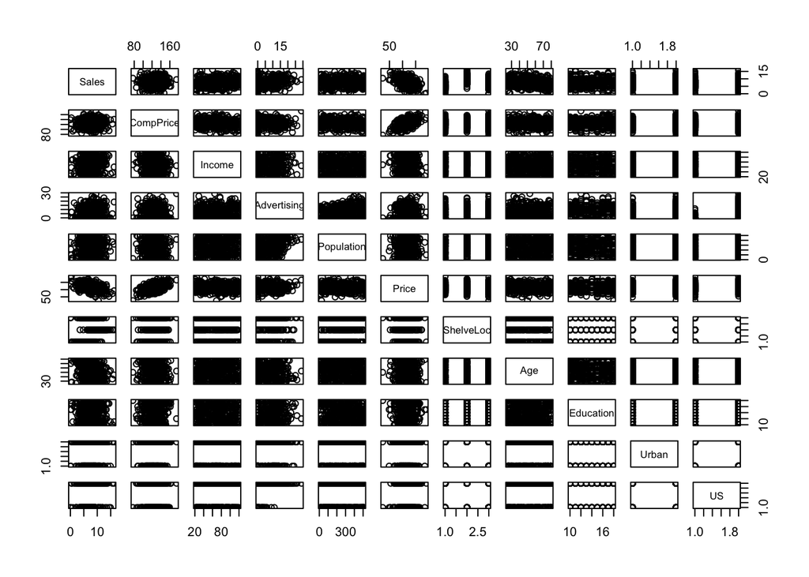

```r
pairs(Carseats[1:11])
```

```r
library(MASS)
lmstrt = lm(Sales ~ 1, data = Carseats)
lmend = lm(Sales ~ ., data = Carseats)
lm.forward = stepAIC(lmstrt, direction = "forward", scope = list(upper = lmend, lower = lmstrt))
```

```
## Start:  AIC=831.55
## Sales ~ 1
##
##               Df Sum of Sq    RSS    AIC
## + ShelveLoc    2   1009.53 2172.7 682.91
## + Price        1    630.03 2552.2 745.31
## + Advertising  1    231.14 2951.1 803.39
## + Age          1    171.01 3011.3 811.46
## + US           1     99.80 3082.5 820.81
## + Income       1     73.48 3108.8 824.21
## <none>                     3182.3 831.55
## + CompPrice    1     13.07 3169.2 831.91
## + Education    1      8.59 3173.7 832.47
## + Population   1      8.11 3174.2 832.53
## + Urban        1      0.76 3181.5 833.46
##
## Step:  AIC=682.91
## Sales ~ ShelveLoc
##
##               Df Sum of Sq    RSS    AIC
## + Price        1    717.10 1455.6 524.69
## + Advertising  1    178.35 1994.4 650.65
## + Age          1    175.00 1997.8 651.32
## + Income       1     99.93 2072.8 666.08
## + US           1     66.54 2106.2 672.47
## <none>                     2172.7 682.91
## + Population   1     10.71 2162.0 682.94
## + CompPrice    1      6.00 2166.7 683.81
## + Education    1      4.19 2168.6 684.14
## + Urban        1      1.70 2171.1 684.60
##
## Step:  AIC=524.69
## Sales ~ ShelveLoc + Price
##
##               Df Sum of Sq     RSS    AIC
## + CompPrice    1    496.96  958.68 359.64
## + Age          1    258.05 1197.59 448.64
## + Advertising  1    209.73 1245.91 464.46
## + US           1     93.07 1362.57 500.26
## + Income       1     73.04 1382.60 506.10
```

[output cut: 35 more lines]

```
## + Education   1     2.488 481.58 90.243
## <none>                    484.07 90.304
## + Urban       1     1.975 482.09 90.669
## + US          1     0.443 483.62 91.937
## + Population  1     0.285 483.78 92.069
##
## Step:  AIC=23.32
## Sales ~ ShelveLoc + Price + CompPrice + Advertising + Age + Income
##
##              Df Sum of Sq    RSS    AIC
## <none>                    407.39 23.320
## + US          1   1.62857 405.76 23.717
## + Education   1   1.22240 406.16 24.117
## + Urban       1   1.18994 406.20 24.149
## + Population  1   0.71569 406.67 24.616
```

```r
summary(lm.forward)
```

```
##
## Call:
## lm(formula = Sales ~ ShelveLoc + Price + CompPrice + Advertising +
##     Age + Income, data = Carseats)
##
## Residuals:
##     Min      1Q  Median      3Q     Max
## -2.7728 -0.6954  0.0282  0.6732  3.3292
##
## Coefficients:
##                  Estimate Std. Error t value Pr(>|t|)
## (Intercept)      5.475226   0.505005   10.84   <2e-16 ***
## ShelveLocGood    4.835675   0.152499   31.71   <2e-16 ***
## ShelveLocMedium  1.951993   0.125375   15.57   <2e-16 ***
## Price           -0.095319   0.002670  -35.70   <2e-16 ***
## CompPrice        0.092571   0.004123   22.45   <2e-16 ***
## Advertising      0.115903   0.007724   15.01   <2e-16 ***
## Age             -0.046128   0.003177  -14.52   <2e-16 ***
## Income           0.015785   0.001838    8.59   <2e-16 ***
## ---
## Signif. codes:  0 '***' 0.001 '**' 0.01 '*' 0.05 '.' 0.1 ' ' 1
##
## Residual standard error: 1.019 on 392 degrees of freedom
## Multiple R-squared:  0.872,  Adjusted R-squared:  0.8697
## F-statistic: 381.4 on 7 and 392 DF,  p-value: < 2.2e-16
```

4. We see as a result of the stepwise, we can see that shelf location within the store (coefficient: 4.836 increase in mean sales per unit), price (coefficient: -0.095 increase in mean sales per unit), competitor pricing (coefficient: 0.092 increase in mean sales per unit), advertising budget (coefficient: 0.116 increase in mean sales per unit), populous age (coefficient: -0.046 increase in mean sales per unit), and community income (coefficient: 0.016 increase in mean sales per unit) are the most important predictors.

```r
confint(lm.forward, level = 0.9)
```

```
##                         5 %        95 %
## (Intercept)      4.64259839  6.30785408
## ShelveLocGood    4.58424242  5.08710707
## ShelveLocMedium  1.74528054  2.15870478
## Price           -0.09972127 -0.09091664
## CompPrice        0.08577323  0.09936971
## Advertising      0.10316913  0.12863768
## Age             -0.05136509 -0.04088995
## Income           0.01275515  0.01881479
```

```r
library(lmvar)
cv.lm(lm(formula(lm.forward), data = Carseats, x = T, y = T), k = 10)$MSE$mean
```

```
## [1] 1.05734
```

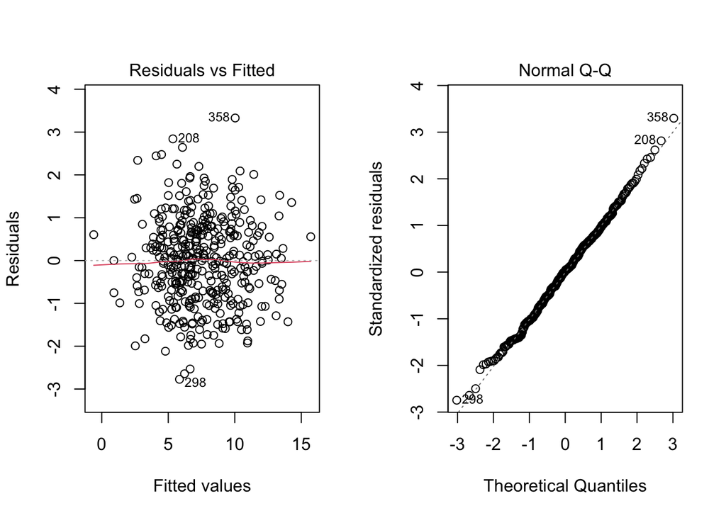

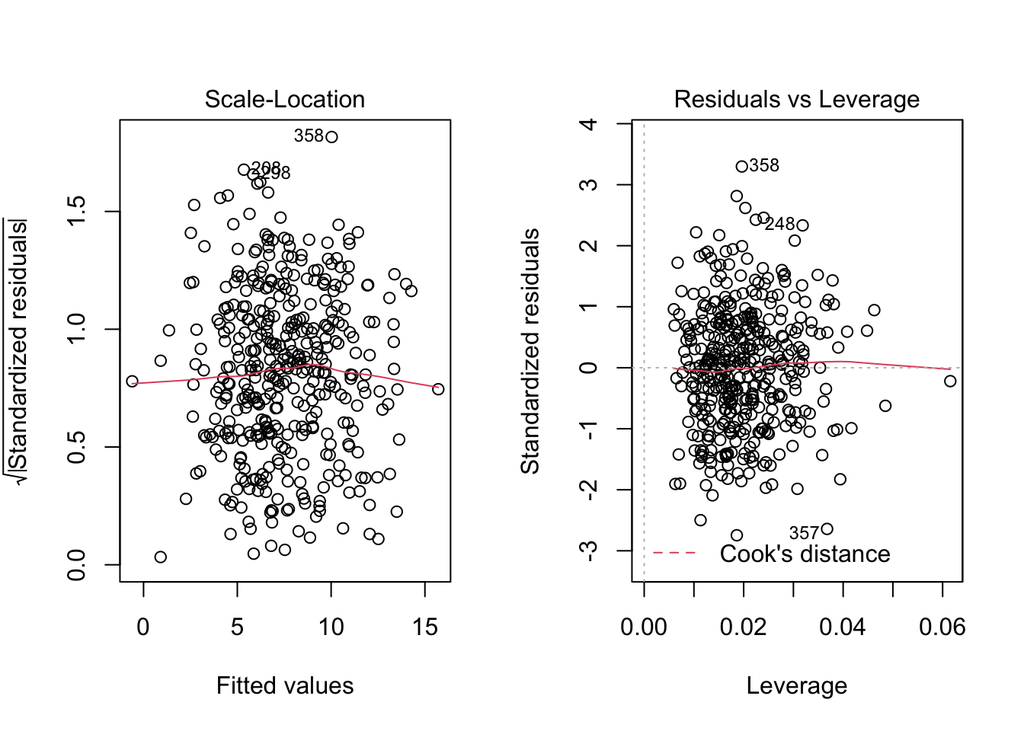

```r
par(mfrow = c(1,2))
plot(lm.forward, whcih = 1:2)
```

For the most part, the residuals indicate only a few deviant points, otherwise, it seems to be in line with assumptions, although not perfect. Thus, it is an appropriate model to use.